# SI 618 WN Project Part III

## Team Members

#### Carlos Figueredo (carlosfc), James Zhu (jazhu)

## Predicting Rurality Level of U.S. Counties based on Demographics

## Overview

Demographic trends in both developed and developing countries are shifting, with notable changes in family size, age distribution, and racial composition. In the United States, analyzing demographic information such as race and age alongside rurality levels provides valuable insights into current birth trends and their broader implications. This project examines how birth counts vary across different degrees of urbanization in U.S. counties, considering the influence of demographic factors. Understanding these relationships is essential for anticipating challenges like labor shortages and reduced economic innovation, as rural and urban areas may experience distinct natality patterns shaped by their unique demographic profiles.

## Data Sources

For this project, we use **3** data sources. As of 2025, all the data is public and accessible through the web.

The first data source is the U.S. Centers for Disease Control and Prevention ([CDC](https://www.cdc.gov/)). Specifically, we use data obtained from the [Natality Information Database](https://wonder.cdc.gov/controller/datarequest/D66). From this database, we extract the birth information for the years 2011 to 2013 for all available counties in the United States. This information is stored in the files `<year>.txt` where `<year>` is replaced by the respective year period. This database provides information at the level of counties, which gives us a high granularity of birth information in the U.S.

The second data source is the U.S. Department of Agriculture ([USDA](https://www.usda.gov/)). Particulary, we use the **2013 Rural-Urban Continuum Codes** available in this [link](https://www.ers.usda.gov/data-products/rural-urban-continuum-codes). All the information is provided by the Economic Research Services Division of the USDA. The information can be downloaded as an Excel file (`.xsl` format), and it is available in the `ruralurbancodes2013.xls` file. This dataset also provides information at the level of counties, and it contains counties' degree of urbanization. Metropolitan counties are categorized by their population size, and nonmetropolitan counties are categorized by their degree of urbanization and adjacency to a metro area.

The third data source is the National Cancer Institute. We use the [County Population Data Dictionary](https://seer.cancer.gov/popdata/popdic.html), which contains subpopulation counts aggregated by race, sex, age groups and origin. This dataset provides for each county a powerful tool for analyzing diversity mixes.

These datasets provide us a joint county-level view of natality, demographics and urbanization.

NOTE: To access the birth count data, visit https://wonder.cdc.gov/natality-current.html. You will need to click "I agree" at the bottom of the page to accept the terms of usage. This will take you to the page where you can download the data.

```python
import pandas as pd
import numpy as np
import seaborn as sns
import matplotlib.pyplot as plt
import gzip
```

# Preprocessing Data

### Birth Counts Dataset

For our first dataset, we need to read the information for 2011, 2012, and 2013. Next, we focus our attention in the Annual Birth Counts, County Code, and the referenced year.

```python
def read_births():
    births = pd.DataFrame()
    for y in range(2011, 2014):
        da = pd.read_csv("%4d.txt" % y, delimiter="\t", dtype={"County Code": object})
        da = da[["County", "County Code", "Births"]]
        da["year"] = y
        births = pd.concat([births, da])
    births = births.dropna()
    births = births.rename({'County Code':'FIPS'}, axis=1)
    unidentified_mask = births['County'].str.contains('Unidentified')
    births = births[~ unidentified_mask]
    births = births.groupby(['FIPS']).agg(Births=('Births', 'mean'),
                                 StdBirths=('Births', 'std'))
    return births

births = read_births()
births.info()
```

```
<class 'pandas.core.frame.DataFrame'>
Index: 524 entries, 01003 to 55139
Data columns (total 2 columns):
 #   Column     Non-Null Count  Dtype
---  ------     --------------  -----
 0   Births     524 non-null    float64
 1   StdBirths  524 non-null    float64
dtypes: float64(2)
memory usage: 12.3+ KB
```

Notice that the births dataset provides restricted information because it only covers 524 different counties.

### Demographics Dataset

For our second dataset, we read the information for the year 2016. Then, we read the fixed width formatted text file to extract the different demographic features. We focus our attention on `Race` and `Age` because they can discriminate better over the rurality level. Generally, `Sex` is similar for **Male** and **Female**, so we don't consider this demographic feature.

```python
def read_demog():
    grid = [1, 5, 7, 9, 12, 14, 15, 16, 17, 19, 27]
    ranges = [(grid[i]-1, grid[i+1]-1) for i in range(len(grid)-1)]
    with gzip.open("2016ages.txt.gz") as io:
        demog = pd.read_fwf(io, colspecs=ranges, header=None)
    demog.columns = ["Year", "State", "StateFIPS", "CountyFIPS", "Registry",
                    "Race", "Origin", "Sex", "Age", "Population"]
    demog["FIPS"] = ["%02d%03d" % (x, y) for (x, y) in zip(demog.StateFIPS, demog.CountyFIPS)]
    demog = demog[["FIPS", "Race", "Age", "Population"]]
    demog["Race"] = demog["Race"].replace([1, 2, 3, 4], ["W", "B", "N", "A"]) # White/Black/Native/Asian
    # Age group labels (For Reference)
    age_groups = ["0", "1-4", "5-9", "10-14", "15-19", "20-24", "25-29", "30-34", "35-39",
                "40-44", "45-49", "50-54", "55-59", "60-64", "65-69", "70-74", "75-79",
                "80-84", "85-89", "90+"]
    return demog

def pivot_demog(demog):
    demog = demog.pivot_table(index="FIPS", columns=["Race", "Age"], values="Population", aggfunc="sum")
    na = demog.columns.tolist()
    demog.columns = ["%s:%d" % tuple(x) for x in na]
    demog = demog.fillna(0)
    return demog

demog = read_demog()
demog = pivot_demog(demog)
print(f"Number of Different Counties: {len(demog)}")
demog.head()
```

```
Number of Different Counties: 3142
```

| FIPS | A:0 | A:1 | A:2 | A:3 | A:4 | A:5 | A:6 | A:7 | A:8 | A:9 | ... | W:10 | W:11 | W:12 | W:13 | W:14 | W:15 | W:16 | W:17 | W:18 | W:19 |
| --- | --- | --- | --- | --- | --- | --- | --- | --- | --- | --- | --- | --- | --- | --- | --- | --- | --- | --- | --- | --- | --- |
| 01001 | 12.0 | 59.0 | 55.0 | 64.0 | 62.0 | 61.0 | 45.0 | 66.0 | 88.0 | 74.0 | ... | 3270.0 | 3320.0 | 3151.0 | 2544.0 | 2278.0 | 1829.0 | 1333.0 | 918.0 | 443.0 | 199.0 |
| 01003 | 28.0 | 135.0 | 176.0 | 233.0 | 313.0 | 181.0 | 179.0 | 149.0 | 267.0 | 195.0 | ... | 12486.0 | 13048.0 | 13598.0 | 13186.0 | 13052.0 | 9885.0 | 6836.0 | 4286.0 | 2401.0 | 1247.0 |
| 01005 | 3.0 | 4.0 | 13.0 | 10.0 | 10.0 | 12.0 | 16.0 | 14.0 | 16.0 | 14.0 | ... | 866.0 | 936.0 | 940.0 | 960.0 | 980.0 | 823.0 | 527.0 | 365.0 | 194.0 | 101.0 |
| 01007 | 0.0 | 5.0 | 2.0 | 7.0 | 9.0 | 4.0 | 14.0 | 8.0 | 7.0 | 4.0 | ... | 1282.0 | 1337.0 | 1205.0 | 1093.0 | 1042.0 | 771.0 | 577.0 | 352.0 | 204.0 | 90.0 |
| 01009 | 4.0 | 26.0 | 33.0 | 19.0 | 22.0 | 20.0 | 16.0 | 15.0 | 19.0 | 22.0 | ... | 3938.0 | 3974.0 | 3824.0 | 3629.0 | 3409.0 | 2602.0 | 1772.0 | 1185.0 | 634.0 | 316.0 |

5 rows × 80 columns

Notice that this dataset is much richer in terms of counties because it contains 3142 different U.S. counties.

The codes in the columns above has the following meanings.

#### Race

| A | B | N | W |
| --- | --- | --- | --- |
| Asian | Black | Native | White |

#### Age Group Label

| Age Label | 0 | 1 | 2 | 3 | 4 | 5 | 6 | 7 | 8 | 9 |
| --- | --- | --- | --- | --- | --- | --- | --- | --- | --- | --- |
| Years | 0 | 1-4 | 5-9 | 10-14 | 15-19 | 20-24 | 25-29 | 30-34 | 35-39 | 40-44 |

$\quad$

| 10 | 11 | 12 | 13 | 14 | 15 | 16 | 17 | 18 | 19 |
| --- | --- | --- | --- | --- | --- | --- | --- | --- | --- |
| 45-49 | 50-54 | 55-59 | 60-64 | 65-69 | 70-74 | 75-79 | 80-84 | 85-89 | 90+ |

### Rural Codes Dataset

Now, we focus our attention in the third dataset. This contains information about urbanization and rurality levels for counties in the U.S. We read this data from an excel file, for which we need the `xlrd` library. This contains the **target** variable for our classification problem.

```python
def read_rucc():
    rucc = pd.read_excel("ruralurbancodes2013.xls", sheet_name=None) # Requires xlrd. Run pip install xlrd
    rucc = rucc["Rural-urban Continuum Code 2013"] # Get first sheet
    rucc["FIPS"] = ["%05d" % x for x in rucc.FIPS] # FIPS to object dtype
    rucc['RUCC_Category'] = rucc['RUCC_2013'].apply(lambda x: "Metro" if x <= 3 else "Nonmetro")
    rucc = rucc.dropna()
    return rucc

rucc = read_rucc()
print(f"Number of Different Counties: {rucc['FIPS'].nunique()}")
rucc.head()
```

```
Number of Different Counties: 3232
```

|  | FIPS | State | County_Name | Population_2010 | RUCC_2013 | Description | RUCC_Category |
| --- | --- | --- | --- | --- | --- | --- | --- |
| 0 | 01001 | AL | Autauga County | 54571 | 2.0 | Metro - Counties in metro areas of 250,000 to ... | Metro |
| 1 | 01003 | AL | Baldwin County | 182265 | 3.0 | Metro - Counties in metro areas of fewer than ... | Metro |
| 2 | 01005 | AL | Barbour County | 27457 | 6.0 | Nonmetro - Urban population of 2,500 to 19,999... | Nonmetro |
| 3 | 01007 | AL | Bibb County | 22915 | 1.0 | Metro - Counties in metro areas of 1 million p... | Metro |
| 4 | 01009 | AL | Blount County | 57322 | 1.0 | Metro - Counties in metro areas of 1 million p... | Metro |

This dataset contains information about 3232 different U.S. Counties.

## Data Manipulation - Population Normalization

We focus our attention in merging all the data sources.

Since rurality can be easily predicted by using popularity, we normalize the counts by populations. Specifically, the subpopulation demographics are normalized. Birth counts are also normalied.

```python
def read_data(drop_FIPS=False):
    births = read_births()
    demog = read_demog()
    demog = pivot_demog(demog)
    demog_sum = demog.sum(axis=1).to_frame()
    demog_sum.columns = ["Population"]
    births_demog = pd.merge(births, demog_sum, on="FIPS")
    births_demog["Births"] = births_demog["Births"] / births_demog["Population"]
    births_demog["StdBirths"] = births_demog["StdBirths"] / births_demog["Population"]
    births_demog = births_demog.drop(columns=["Population"])
    norm_demog = demog.div(demog.sum(axis=1), axis=0)
    df = pd.merge(births_demog, norm_demog, on="FIPS", how="right")
    rucc = read_rucc()[["FIPS", "RUCC_Category"]]
    rucc["Metro"] = rucc["RUCC_Category"].apply(lambda x: 1 if x == "Metro" else 0)
    rucc = rucc.drop(columns=["RUCC_Category"])
    df = pd.merge(df, rucc, on="FIPS")
    if drop_FIPS:
        df = df.drop(columns=["FIPS"])
    else:
        df = df.set_index("FIPS")
    return df

df = read_data()
```

```python
df.head()
```

| FIPS | Births | StdBirths | A:0 | A:1 | A:2 | A:3 | A:4 | A:5 | A:6 | A:7 | ... | W:11 | W:12 | W:13 | W:14 | W:15 | W:16 | W:17 | W:18 | W:19 | Metro |
| --- | --- | --- | --- | --- | --- | --- | --- | --- | --- | --- | --- | --- | --- | --- | --- | --- | --- | --- | --- | --- | --- |
| 01001 | NaN | NaN | 0.000211 | 0.001036 | 0.000966 | 0.001124 | 0.001089 | 0.001071 | 0.000790 | 0.001159 | ... | 0.058304 | 0.055336 | 0.044676 | 0.040005 | 0.032120 | 0.023409 | 0.016121 | 0.007780 | 0.003495 | 1 |
| 01003 | 0.010208 | 0.000136 | 0.000133 | 0.000643 | 0.000839 | 0.001110 | 0.001492 | 0.000863 | 0.000853 | 0.000710 | ... | 0.062183 | 0.064804 | 0.062841 | 0.062202 | 0.047109 | 0.032578 | 0.020426 | 0.011442 | 0.005943 | 1 |
| 01005 | NaN | NaN | 0.000114 | 0.000152 | 0.000494 | 0.000380 | 0.000380 | 0.000456 | 0.000608 | 0.000532 | ... | 0.035584 | 0.035736 | 0.036496 | 0.037257 | 0.031288 | 0.020035 | 0.013876 | 0.007375 | 0.003840 | 0 |
| 01007 | NaN | NaN | 0.000000 | 0.000221 | 0.000088 | 0.000309 | 0.000397 | 0.000177 | 0.000618 | 0.000353 | ... | 0.059023 | 0.053196 | 0.048252 | 0.046000 | 0.034037 | 0.025472 | 0.015539 | 0.009006 | 0.003973 | 1 |
| 01009 | NaN | NaN | 0.000069 | 0.000447 | 0.000567 | 0.000326 | 0.000378 | 0.000344 | 0.000275 | 0.000258 | ... | 0.068285 | 0.065708 | 0.062357 | 0.058577 | 0.044710 | 0.030448 | 0.020362 | 0.010894 | 0.005430 | 1 |

5 rows × 83 columns

```python
print(f"Number of Different Counties: {df.shape[0]}")
df.isna().sum()[df.isna().sum() > 0]
```

```
Number of Different Counties: 3141
```

```
Births       2617
StdBirths    2617
dtype: int64
```

Notice that a big portion of the merged data contains missing information (2617 out of 3141 counties in df).

## Imputation of Births

We impute the value `Births`, and `StdBirths` by labelling as unknown the missing values. Additionally, we set as high or low, dependeing on the median values of these features.

```python
def impute(row, column):
    if pd.isna(row[column]):
        return 'Unknown'
    elif row[column] > df[column].median():
        return 'High'
    else:
        return 'Low'

df['Births'] = df.apply(lambda row: impute(row, 'Births'), axis=1)
df['StdBirths'] = df.apply(lambda row: impute(row, 'StdBirths'), axis=1)
```

```python
df.isna().sum().sum()
```

```
0
```

## Dimension Reduction Analysis

We now analyze the demographics features by using Principal Components Analysis.

```python
from sklearn.preprocessing import StandardScaler
from sklearn.decomposition import PCA
from sklearn.pipeline import Pipeline

df_reduced = df.drop(columns=["Births", "StdBirths", "Metro"])

pca_pipeline = Pipeline([
    ('scaler', StandardScaler()),
    ('pca', PCA(n_components=15))
])

pca_result = pca_pipeline.fit_transform(df_reduced)
```

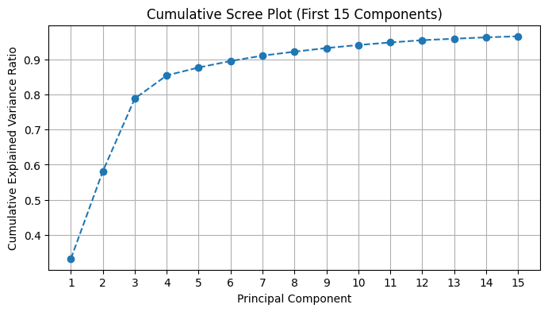

```python
def cumulative_scree_plot():
    plt.figure(figsize=(8, 4))
    plt.plot(range(1, 16), np.cumsum(pca_pipeline.named_steps['pca'].explained_variance_ratio_[:15]), marker='o', linestyle='--')
    plt.title('Cumulative Scree Plot (First 15 Components)')
    plt.xlabel('Principal Component')
    plt.ylabel('Cumulative Explained Variance Ratio')
    plt.xticks(range(1, 16))
    plt.grid()
    plt.show()

cumulative_scree_plot()
```

From the cumulative explained variance ration, we can observe that 4 components is enough to explain 85% of the variance.

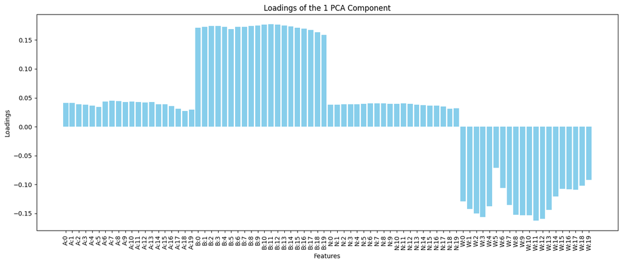

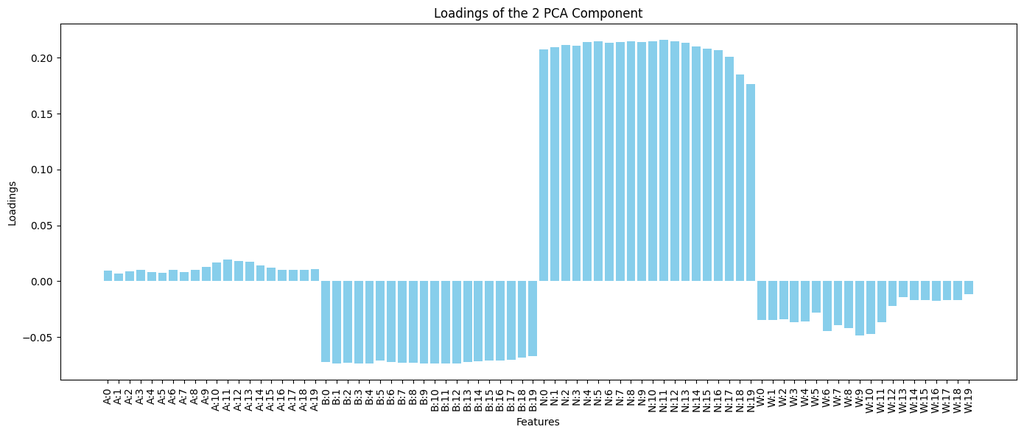

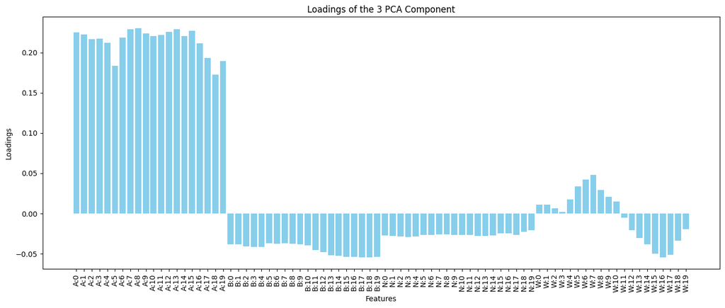

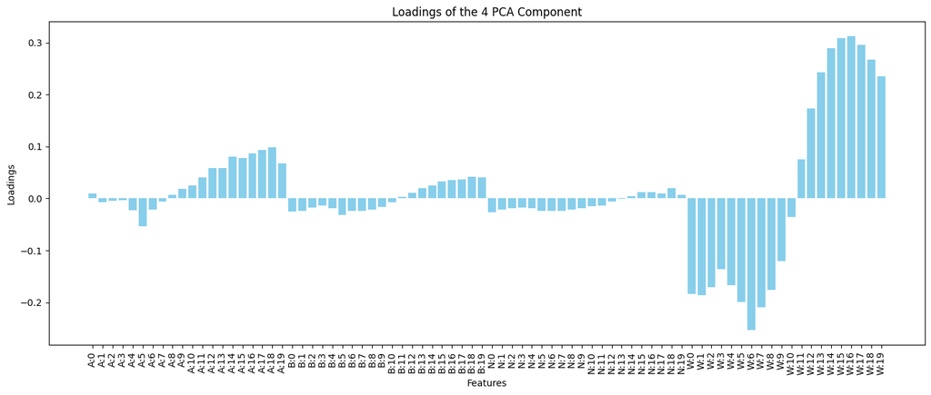

```python
def plot_pca_loadings(k):
    loadings = pca_pipeline.named_steps['pca'].components_[k]
    plt.figure(figsize=(14, 6))
    plt.bar(range(len(loadings)), loadings, tick_label=df_reduced.columns, color='skyblue')
    plt.xticks(rotation=90)
    plt.xlabel('Features')
    plt.ylabel('Loadings')
    plt.title(f'Loadings of the {k+1} PCA Component')
    plt.tight_layout()
    plt.show()

for k in range(4):
    plot_pca_loadings(k)
```

By analyzing the loadings of the PCA components, we can observe that the algorithm is detecting the race in the first 3 components. Thus, the main source of variance between counties is in the race mix. The first component is capturing the relationship of Black and White population. The second component is capturing Native American Population, and the third component is capturing Asian population.

```python
def print_pca_components(fips_code):
    components = pca_pipeline.transform(df_reduced.loc[[fips_code]])[0][:4]
    print(components)

famous_counties = {"LA County": "06037", "Wayne County": "26163"}
for name, code in famous_counties.items():
    print(f"First four PCA components for {name} (FIPS {code}):")
    print_pca_components(code)
```

```
First four PCA components for LA County (FIPS 06037):
[ 4.11720643  0.57494548 15.68110323 -0.56595259]
First four PCA components for Wayne County (FIPS 26163):
[10.41451532 -3.04782961  0.19030408 -0.4858609 ]
```

For LA county we can observe that it is one of the counties with most Asian presence per capita because it scores 15 on the third component. Additionally, Wayne county which contains Detroit has one of the biggest Black presence per capita because it has a high score on the first component.

In conclusion, we used the preprocessing of the dataset as an informative tool to gain understanding of the dataset. First, we normalized the birth and subpopulation counts to eliminate the influence of population in our prediction task. This step makes the prediction focus on the relative proportion of subpopulations rather than raw counts. Secondly, we used PCA to gain insights about the structure of the variance in the demographics. We observed that Black and White population are inversely related (bigger presence of one means lesser presence of the other on average). Additionally, we observed that the main source of variance is the Race because the PCA naturally divided the components by this feature. Finally, we overcame the counties issue of the Birth counts by categorizing the variable. All these steps allow us to be ready to train a classifier that can use demographics and birth counts to predict rurality level.

# Clasification Analysis

We now focus our attention on training classifiers. We develop machine learning classifiers to predict rurality levels in U.S. counties using historical birth records and demographic data. As we observed in the preprocessing step, in some rural counties birth counts aren't available. This is evidence of the logistical burden involved in collecting data of non-urban populations. Moreover, subpopulation counts aren't available for all U.S. counties. There are about 100 counties that don't have this information. Many rural counties lack complete birth and subpopulation statistics, which poses significant challenges for policymakers. Thus, classifying rurality based on past information and demographics is relevant to policymakers. Finally, analyzing the relationship between demographic factors and rurality can reveal important patterns—such as the role of race—that inform data-driven policy decisions.

```python
from sklearn.model_selection import train_test_split
from sklearn.compose import ColumnTransformer
from sklearn.preprocessing import OneHotEncoder
from sklearn.pipeline import Pipeline
from sklearn.ensemble import RandomForestClassifier
from sklearn.metrics import classification_report, confusion_matrix
from xgboost import XGBClassifier, plot_importance
from sklearn.model_selection import RandomizedSearchCV
from scipy.stats import randint, uniform
```

```python
X = df.drop(columns=["Metro"])
y = df["Metro"]
X_train, X_test, y_train, y_test = train_test_split(X, y, test_size=0.2, random_state=42)
```

```python
onehot_encoder = ColumnTransformer(
    transformers=[
        ('onehot', OneHotEncoder(), ['Births', 'StdBirths']),
    ],
    remainder='passthrough'  # Keep other columns as is
)
model = Pipeline([
    ('preprocessor', onehot_encoder),
    ('classifier', RandomForestClassifier(n_estimators=100, random_state=42))
])
```

```python
model.fit(X_train, y_train)

# Predict on the test data
y_pred = model.predict(X_test)
# Print classification report
print(classification_report(y_test, y_pred))
# Print confusion matrix
print(confusion_matrix(y_test, y_pred))
```

```
              precision    recall  f1-score   support

           0       0.83      0.94      0.88       406
           1       0.86      0.65      0.74       223

    accuracy                           0.84       629
   macro avg       0.85      0.79      0.81       629
weighted avg       0.84      0.84      0.83       629

[[383  23]
 [ 79 144]]
```

```python
# Same pipeline
pipeline = Pipeline([
    ('preprocessor', onehot_encoder),
    ('classifier', RandomForestClassifier(random_state=42))
])

# Randomized parameter distributions
param_dist = {
    'classifier__n_estimators': randint(100, 300),
    'classifier__max_depth': [None, 10, 20, 30],
    'classifier__min_samples_split': randint(2, 11),
    'classifier__min_samples_leaf': randint(1, 5),
    'classifier__max_features': ['sqrt', 'log2']
}

# RandomizedSearchCV
random_search = RandomizedSearchCV(
    estimator=pipeline,
    param_distributions=param_dist,
    n_iter=20,
    cv=3,
    scoring='accuracy',
    n_jobs=-1,
    verbose=1,
    random_state=42
)

random_search.fit(X_train, y_train)

# Evaluation
best_model = random_search.best_estimator_
y_pred = best_model.predict(X_test)

print("Best Parameters:", random_search.best_params_)
print(classification_report(y_test, y_pred))
print(confusion_matrix(y_test, y_pred))
```

```
Fitting 3 folds for each of 20 candidates, totalling 60 fits
Best Parameters: {'classifier__max_depth': 20, 'classifier__max_features': 'sqrt', 'classifier__min_samples_leaf': 3, 'classifier__min_samples_split': 4, 'classifier__n_estimators': 207}
              precision    recall  f1-score   support

           0       0.83      0.95      0.89       406
           1       0.88      0.65      0.75       223

    accuracy                           0.85       629
   macro avg       0.86      0.80      0.82       629
weighted avg       0.85      0.85      0.84       629

[[387  19]
 [ 78 145]]
```

```python
# For XGBoost, need to convert 2 column to numeric

# Define the encoding map
label_map = {"Unknown": 0, "Low": 1, "High": 2}

# Apply to both columns
df["Births"] = df["Births"].map(label_map)
df["StdBirths"] = df["StdBirths"].map(label_map)
```

```
              precision    recall  f1-score   support

           0       0.83      0.95      0.89       406
           1       0.88      0.65      0.75       223

    accuracy                           0.85       629
   macro avg       0.86      0.80      0.82       629
weighted avg       0.85      0.85      0.84       629
```

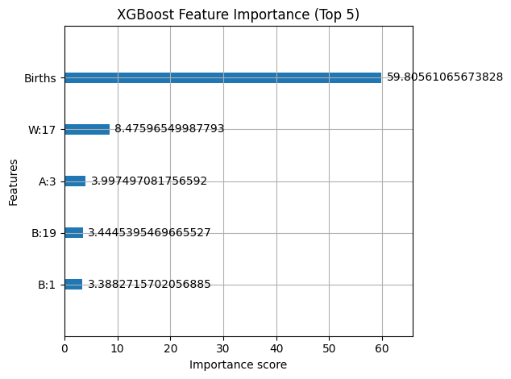

```python
X = df.drop(columns=["Metro"])
y = df["Metro"]
X_train, X_test, y_train, y_test = train_test_split(X, y, test_size=0.2, random_state=42)

# Train XGBoost classifier
xgb = XGBClassifier()
xgb.fit(X_train, y_train)

# Evaluate
print(classification_report(y_test, y_pred))

# Plot feature importance
plt.figure(figsize=(10, 8))
plot_importance(xgb, max_num_features=5, importance_type='gain')
plt.title("XGBoost Feature Importance (Top 5)")
plt.tight_layout()
plt.show()
```

```python
xgb = XGBClassifier(use_label_encoder=False, eval_metric='logloss', random_state=42)

# Parameter distributions
param_dist = {
    'n_estimators': randint(100, 300),
    'max_depth': randint(3, 10),
    'learning_rate': uniform(0.01, 0.3),
    'subsample': uniform(0.6, 0.4),
    'colsample_bytree': uniform(0.6, 0.4),
    'gamma': uniform(0, 5),
    'reg_lambda': uniform(0, 5),
    'reg_alpha': uniform(0, 5)
}

# Randomized search
random_search = RandomizedSearchCV(
    estimator=xgb,
    param_distributions=param_dist,
    n_iter=20,
    scoring='accuracy',
    cv=3,
    verbose=1,
    random_state=42,
    n_jobs=-1
)

random_search.fit(X_train, y_train)

best_xgb = random_search.best_estimator_

# Predict and evaluate
y_pred = best_xgb.predict(X_test)
print("Best Params:", random_search.best_params_)
print(classification_report(y_test, y_pred))
```

```
Fitting 3 folds for each of 20 candidates, totalling 60 fits
```

```
Best Params: {'colsample_bytree': 0.8428136990746738, 'gamma': 1.3799959101127168, 'learning_rate': 0.09888205171122472, 'max_depth': 7, 'n_estimators': 164, 'reg_alpha': 0.07818203370596966, 'reg_lambda': 2.117007403531848, 'subsample': 0.7579526072702278}
              precision    recall  f1-score   support

           0       0.84      0.92      0.88       406
           1       0.82      0.67      0.74       223

    accuracy                           0.83       629
   macro avg       0.83      0.80      0.81       629
weighted avg       0.83      0.83      0.83       629
```

## INTERPRETATIONS

To evaluate the effectiveness of our models in predicting the rurality level of U.S. counties, we trained and compared two classifiers: a Random Forest Classifier and an XGBoost Classifier, using a target variable representing rural versus urban status. Both classifiers were optimized using randomized grid search with 3-fold cross-validation.